# Part II - Exploration Findings

## Distribution of Member Gender by User Type

> This visualization compares the distribution of `member_gender` between user types. It shows that a higher proportion of male users are subscribers compared to female users.

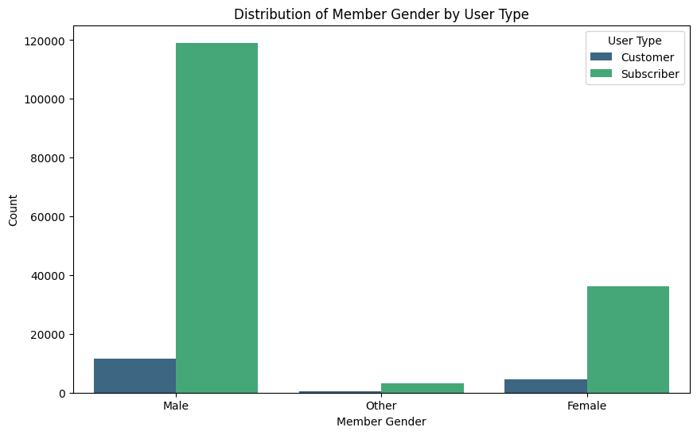

```python
plt.figure(figsize=(10, 6))

# Plotting the distribution of member gender by user type
sns.countplot(data=df, x='member_gender', hue='user_type', palette='viridis')

# Adding title and labels
plt.title('Distribution of Member Gender by User Type')
plt.xlabel('Member Gender')
plt.ylabel('Count')

# Adding legend
plt.legend(title='User Type')

# Display the plot
plt.show()
```

## Distribution of the average trip duration by user type

> This visualization shows the average trip duration for each `member_gender` grouped by `user_type`. It helps to identify if there is a significant difference in the trip durations between male and female users for subscribers and customers.

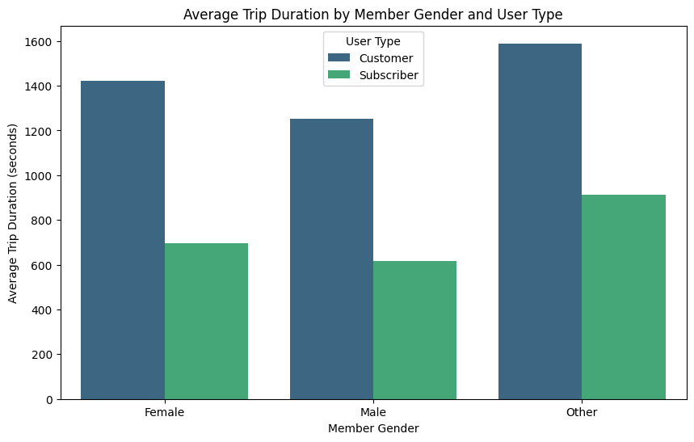

```python
# Calculate the average trip duration for each gender by user type
avg_trip_duration = df.groupby(['member_gender', 'user_type'])['duration_sec'].mean().reset_index()

# Plotting the average trip duration by user type
plt.figure(figsize=(10, 6))

sns.barplot(data=avg_trip_duration, x='member_gender', y='duration_sec', hue='user_type', palette='viridis')

# Adding title and labels
plt.title('Average Trip Duration by Member Gender and User Type')
plt.xlabel('Member Gender')
plt.ylabel('Average Trip Duration (seconds)')

# Adding legend
plt.legend(title='User Type')

# Display the plot
plt.show()
```